# Visualization Project

Arvind Raghavendran MDS202214

2022-10-30

### Abstract

##### The project is an attempt to visually depict and analyze the World Happiness Report and key factors that affect the same. We begin with a brief overview about the data and the various features present. We then perform EDA and present some key graphs whilst drawing conclusions from them and finish with a peek into the analysis the dashboard would provide in later stages.

### Introduction

##### The World Happiness Report survey of the state of global happiness. The first report was published in 2012. The World Happiness 2019 ranked 155 countries by their happiness levels. The report continues to gain global recognition as governments, organizations and civil society increasingly use happiness indicators to inform their policy-making decisions. Leading experts across fields describe how measurements of well-being can be used effectively to assess the progress of nations. The reports review the state of happiness in the world today and show how the new science of happiness explains personal and national variations in happiness.

### About the data

##### The data was available as 5 files, each for the years 2015-2019. The factors (variables) in the data are GDP per capita, relationship with Family, Life Expectancy, Freedom offered by the government, Generosity of the people and Trust in the government. We will take a look at the central tendencies concerning the spread of happiness in 2019.

|  | Central Tendency | Happiness Score | GDP | Family | Life Expectancy | Freedom | Generosity | Trust in Government |
| --- | --- | --- | --- | --- | --- | --- | --- | --- |
| 1 | Mean | 5.407 | 0.905 | 1.209 | 0.725 | 0.393 | 0.185 | 0.111 |
| 2 | Median | 5.38 | 0.96 | 1.272 | 0.789 | 0.417 | 0.178 | 0.086 |
| 3 | Variance | 1.239 | 0.159 | 0.09 | 0.059 | 0.021 | 0.009 | 0.009 |
| 4 | Standard Deviation | 1.113 | 0.398 | 0.299 | 0.242 | 0.143 | 0.095 | 0.095 |
| 5 | Max | 7.769 | 1.684 | 1.624 | 1.141 | 0.631 | 0.566 | 0.453 |
| 6 | Min | 2.853 | 0 | 0 | 0 | 0 | 0 | 0 |

##### A point to be observed would be the relatively large variance in Happiness Score, indicating that there is a disproportionate spread of happiness throughout the world. Let us look at this trend in the past.

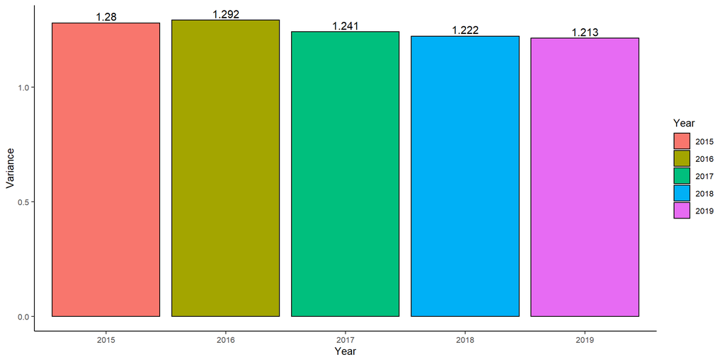

##### As seen above, the disproportionate spread in happiness shows a decreasing trend, albeit having always been relatively high.

### Trend in World Happiness

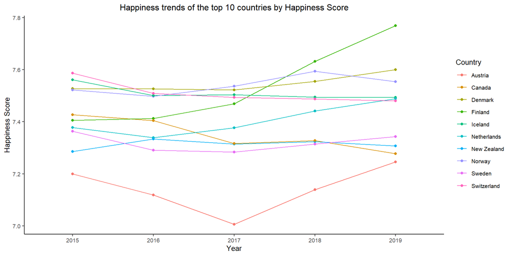

##### We see varying trends in the happiness over the years, but it is evident that Finland’s situation has improved drastically from 2017 and it has been the happiest country for the past 2 years. Austria saw a steep dip in 2017 but it has since recovered. The other countries have maintained a steady state of their condition.

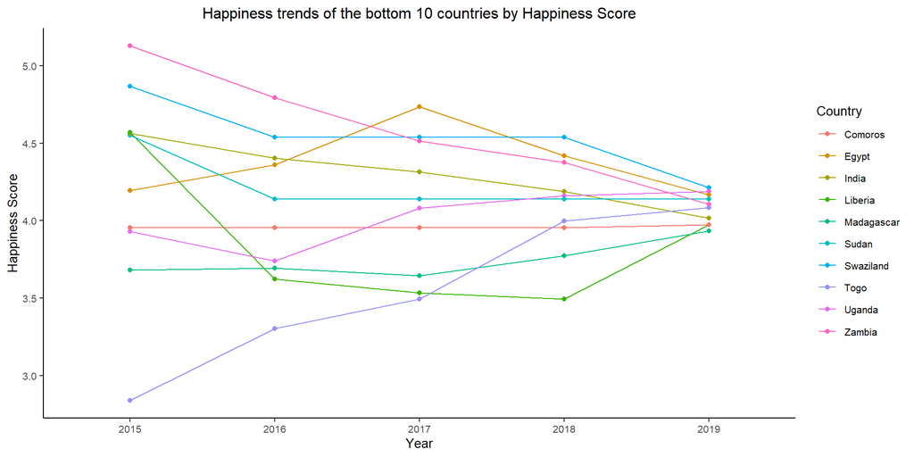

### Effect of Life Expectancy on Happiness

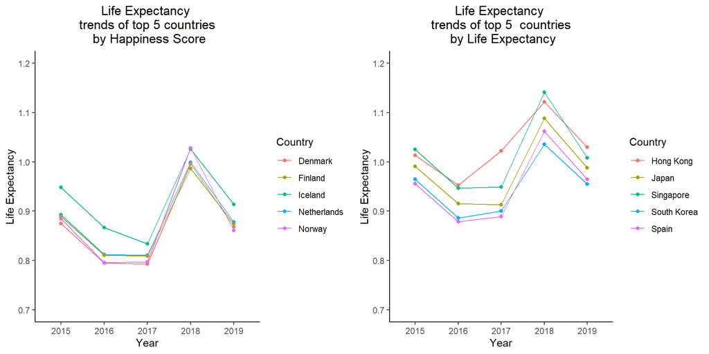

##### With respect to the distribution of life expectancies of the top countries by the same, it can be seen that the top countries by happiness also have a high life expectancy. This can indicate that people who are assured to live longer tend to be happier.

### Effect of GDP Per Capita on Happiness

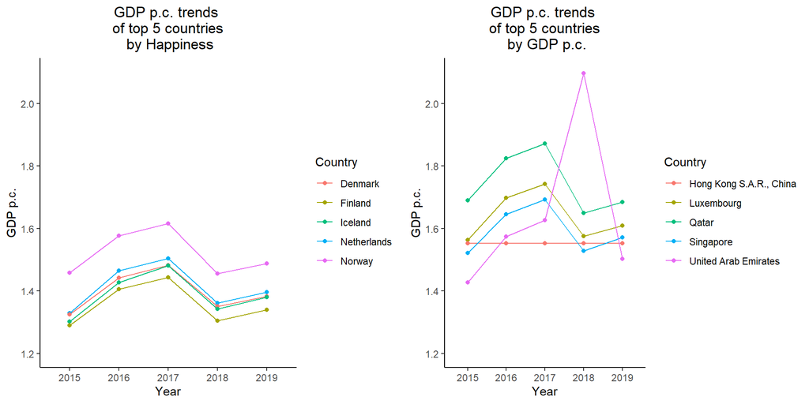

##### With respect to the distribution of GDP p.c. of the top countries by the same, it can be seen that the GDP p.c. of the top countries by happiness is not among the top values, but it is still relatively high. This indicates that GDP p.c. is also a very important factor that governs world happiness. The above graphs indicate a possible causal relationship between Happiness and certain factors. This will be made clear as we study the correlation plot.

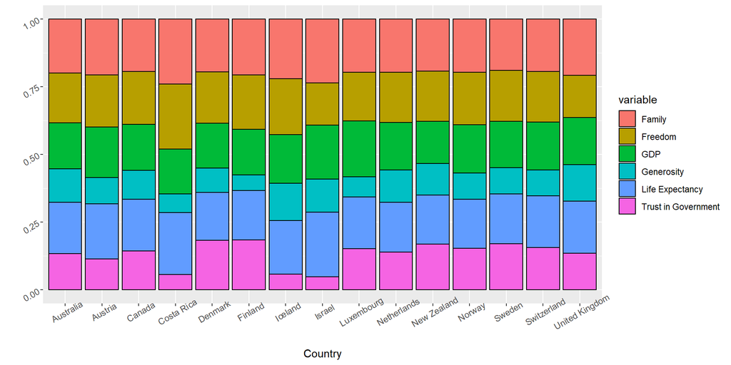

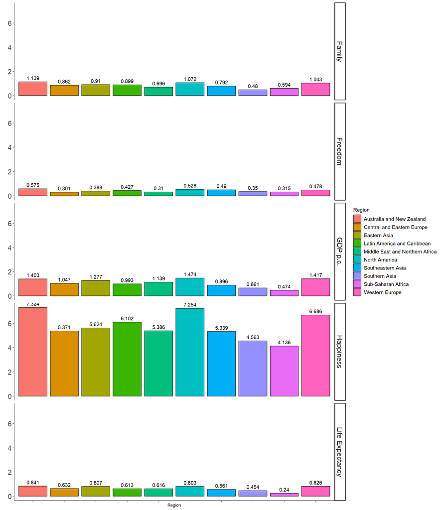

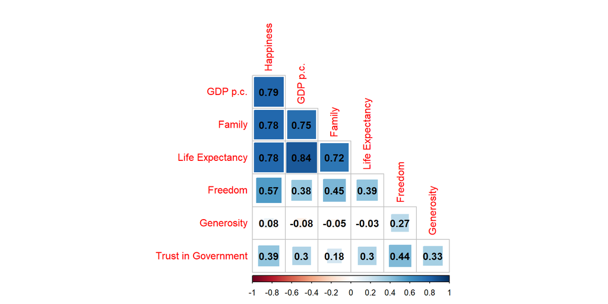

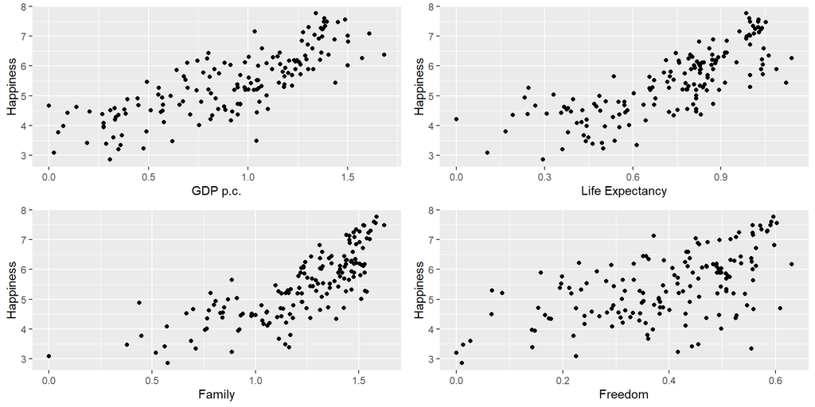